# Data Education Workshop 1

Copyright 2021 Lara Rostomian All Rights Reserved

## Introduction

The Center for Systems Science and Engineering at Johns Hopkins was among the earliest to collect and publish global data related to the COVID-19 pandemic. The data used for their [reporting dashboard](https://coronavirus.jhu.edu/map.html), aggregated from multiple sources and updated daily, is freely available on [Github](https://github.com/CSSEGISandData/COVID-19).

We will review a basic overview of the following steps in data analysis:

1. Data Import and Cleaning
2. Exploratory Data Analysis & Visualization
3. Predictive Modeling: Regression and Classification

### Setting Up R:

If you’re brand new to R, **welcome** we recommend you check out [RSwirl](https://swirlstats.com/students.html) if you haven’t already to learn how to set up R and learn some of the basics!

1. Create New Project (Via Github Repository) & Establish Working Directory
2. Create a File (RMD)
3. Load Packages Chunk

### Load Packages:

First use install.packages() then library()

```r
library(tidyr) # Getting Data in Tidy Format
library(tidyverse) # Holy Grail
library(dplyr) # Holy Grail Pt 2
library(lubridate) # Manipulating Data
library(zoo) # Manipulating Data
```

```r
library(maps) # Mapping Visualizations
library(ggplot2) # All Visualizations
library(ggthemes) # All Visualizations Themes
library(readxl) # Read in Excel Files
library(splitstackshape) #Prediction Modeling Functions
library(readxl) #Read In Excel Files
library(caret) #Confusion Matrix
```

## Data Import and Cleaning

Step 0: Finding Data (Look for CSV Files!) Step 1: Read in data for (Make sure you either use raw data link if available or import your CSV file into the same working directory as your Rmd file.) Step 2: View Data & Decide What Needs to be “Cleaned”  
Step 3: Data Cleaning!

```r
#Reading in the case data
cases <- read_csv("https://raw.githubusercontent.com/CSSEGISandData/COVID-19/master/csse_covid_19_data/csse_covid_19_time_series/time_series_covid19_confirmed_global.csv")
head(cases)
```

```
## # A tibble: 6 x 399
##   `Province/State` `Country/Region`   Lat   Long `1/22/20` `1/23/20` `1/24/20`
##   <chr>            <chr>            <dbl>  <dbl>     <dbl>     <dbl>     <dbl>
## 1 <NA>             Afghanistan       33.9  67.7          0         0         0
## 2 <NA>             Albania           41.2  20.2          0         0         0
## 3 <NA>             Algeria           28.0   1.66         0         0         0
## 4 <NA>             Andorra           42.5   1.52         0         0         0
## 5 <NA>             Angola           -11.2  17.9          0         0         0
## 6 <NA>             Antigua and Bar…  17.1 -61.8          0         0         0
## # … with 392 more variables: `1/25/20` <dbl>, `1/26/20` <dbl>, `1/27/20` <dbl>,
## #   `1/28/20` <dbl>, `1/29/20` <dbl>, `1/30/20` <dbl>, `1/31/20` <dbl>,
## #   `2/1/20` <dbl>, `2/2/20` <dbl>, `2/3/20` <dbl>, `2/4/20` <dbl>,
## #   `2/5/20` <dbl>, `2/6/20` <dbl>, `2/7/20` <dbl>, `2/8/20` <dbl>,
## #   `2/9/20` <dbl>, `2/10/20` <dbl>, `2/11/20` <dbl>, `2/12/20` <dbl>,
## #   `2/13/20` <dbl>, `2/14/20` <dbl>, `2/15/20` <dbl>, `2/16/20` <dbl>,
## #   `2/17/20` <dbl>, `2/18/20` <dbl>, `2/19/20` <dbl>, `2/20/20` <dbl>,
## #   `2/21/20` <dbl>, `2/22/20` <dbl>, `2/23/20` <dbl>, `2/24/20` <dbl>,
## #   `2/25/20` <dbl>, `2/26/20` <dbl>, `2/27/20` <dbl>, `2/28/20` <dbl>,
## #   `2/29/20` <dbl>, `3/1/20` <dbl>, `3/2/20` <dbl>, `3/3/20` <dbl>,
## #   `3/4/20` <dbl>, `3/5/20` <dbl>, `3/6/20` <dbl>, `3/7/20` <dbl>,
## #   `3/8/20` <dbl>, `3/9/20` <dbl>, `3/10/20` <dbl>, `3/11/20` <dbl>,
## #   `3/12/20` <dbl>, `3/13/20` <dbl>, `3/14/20` <dbl>, `3/15/20` <dbl>,
## #   `3/16/20` <dbl>, `3/17/20` <dbl>, `3/18/20` <dbl>, `3/19/20` <dbl>,
## #   `3/20/20` <dbl>, `3/21/20` <dbl>, `3/22/20` <dbl>, `3/23/20` <dbl>,
## #   `3/24/20` <dbl>, `3/25/20` <dbl>, `3/26/20` <dbl>, `3/27/20` <dbl>,
## #   `3/28/20` <dbl>, `3/29/20` <dbl>, `3/30/20` <dbl>, `3/31/20` <dbl>,
## #   `4/1/20` <dbl>, `4/2/20` <dbl>, `4/3/20` <dbl>, `4/4/20` <dbl>,
## #   `4/5/20` <dbl>, `4/6/20` <dbl>, `4/7/20` <dbl>, `4/8/20` <dbl>,
## #   `4/9/20` <dbl>, `4/10/20` <dbl>, `4/11/20` <dbl>, `4/12/20` <dbl>,
## #   `4/13/20` <dbl>, `4/14/20` <dbl>, `4/15/20` <dbl>, `4/16/20` <dbl>,
## #   `4/17/20` <dbl>, `4/18/20` <dbl>, `4/19/20` <dbl>, `4/20/20` <dbl>,
## #   `4/21/20` <dbl>, `4/22/20` <dbl>, `4/23/20` <dbl>, `4/24/20` <dbl>,
## #   `4/25/20` <dbl>, `4/26/20` <dbl>, `4/27/20` <dbl>, `4/28/20` <dbl>,
## #   `4/29/20` <dbl>, `4/30/20` <dbl>, `5/1/20` <dbl>, `5/2/20` <dbl>,
## #   `5/3/20` <dbl>, …
```

```r
#Check First and Last Date
```

Reshape the data to long format, so that instead of having many columns of cases for each date, you have one column that stores the cases and one column that stores the dates.

```r
cases_long <- cases %>% gather(date, cases, '1/22/20':'2/19/21') #Check Latest Date
head(cases_long)
```

```
## # A tibble: 6 x 6
##   `Province/State` `Country/Region`      Lat   Long date    cases
##   <chr>            <chr>               <dbl>  <dbl> <chr>   <dbl>
## 1 <NA>             Afghanistan          33.9  67.7  1/22/20     0
## 2 <NA>             Albania              41.2  20.2  1/22/20     0
## 3 <NA>             Algeria              28.0   1.66 1/22/20     0
## 4 <NA>             Andorra              42.5   1.52 1/22/20     0
## 5 <NA>             Angola              -11.2  17.9  1/22/20     0
## 6 <NA>             Antigua and Barbuda  17.1 -61.8  1/22/20     0
```

Convert the new date column to be a date class instead of a character class.

```r
#Check Class
class(cases_long$date)
```

```
## [1] "character"
```

```r
cases_long$date <-as.Date(cases_long$date, "%m/%d/%y")

#Re-Check Class
class(cases_long$date)
```

```
## [1] "Date"
```

```r
class(cases_long$cases)
```

```
## [1] "numeric"
```

This data set keeps track of the number of confirmed cases reported for states, provinces, and other sub-regions within a given country but we just want total country data. This data frame also still includes a bunch of other information we’re not interested in (Latitude Longitude Etc…)

We can create a new data frame with only what we’re interested in: country name, date, and the total number of cases in the country on that day.

We can do this by summing up the cases across all of the states/provinces within each country and date.

```r
cases_long_country <- cases_long %>% rename(country ="Country/Region") %>%  group_by(country, date) %>% summarize(cases=sum(cases), .groups = "drop")
head(cases_long_country)
```

```
## # A tibble: 6 x 3
##   country     date       cases
##   <chr>       <date>     <dbl>
## 1 Afghanistan 2020-01-22     0
## 2 Afghanistan 2020-01-23     0
## 3 Afghanistan 2020-01-24     0
## 4 Afghanistan 2020-01-25     0
## 5 Afghanistan 2020-01-26     0
## 6 Afghanistan 2020-01-27     0
```

So now we’re ready for the fun part!

## Exploratory Data Analysis and Visualizations

Step 1: What do we want to explore? Step 2: Whats the best way to visualize it? Step 3: Repeat Steps 1 and 2 Forever

So lets say we want to look at only a few countries first to compare their COVID Cases: Armenia, Azerbaijan, Turkey, Georgia, Russia.

Perhaps the best way to visualize this is a line plot with cases on the Y axis and date on the X axis. But first, we have to restrict our data to only those countries we’re interested in including in our plot.

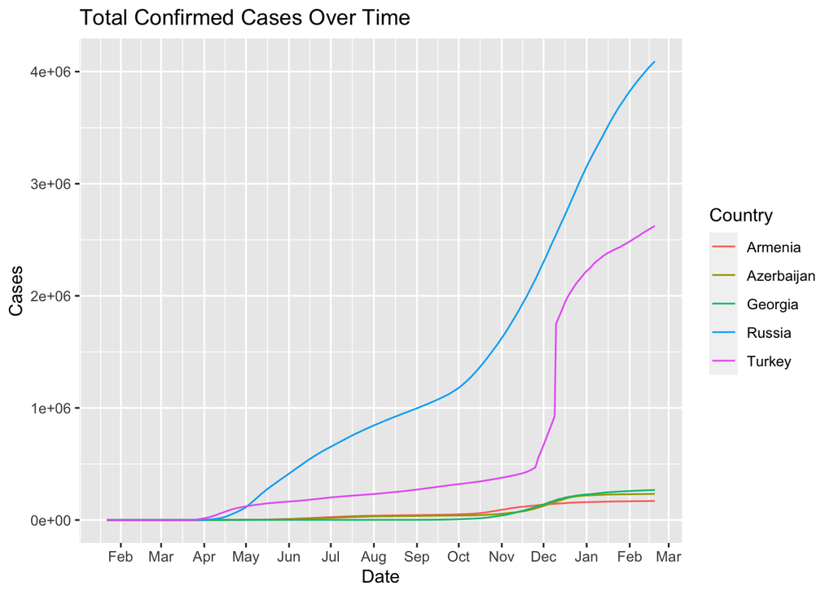

```r
countries = c("Armenia", "Azerbaijan","Turkey","Georgia","Russia")
plot1data <- cases_long_country %>% filter(country %in% countries)
ggplot(plot1data, aes(x=date, y=cases, color=country)) + geom_line() + scale_x_date(date_breaks = "1 month", date_labels = "%b") + labs(x = "Date", y = "Cases", title = "Total Confirmed Cases Over Time") + guides(color = guide_legend(title="Country"))
```

The number of cases varies greatly across these five countries. This stretches out the scale of the y-axis and making it hard to see what’s going on in countries where there are fewer cases. Transforming the data can make it easier to interpret your time series plot. We’re going to redo this same plot but use a log scale transformation (with base 10) for the y-axis.

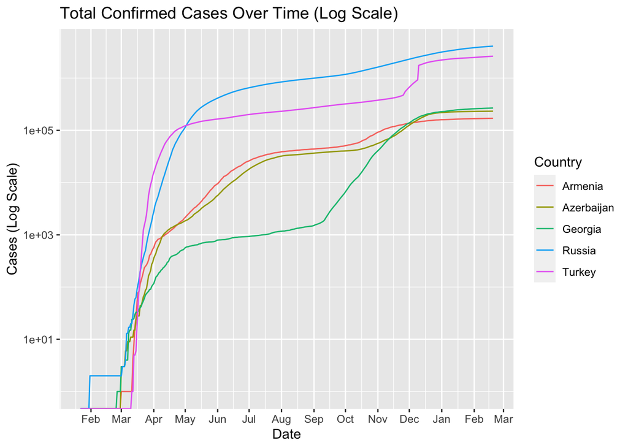

```r
countries = c("Armenia", "Azerbaijan","Turkey","Georgia","Russia")
plot1data <- cases_long_country %>% filter(country %in% countries)
ggplot(plot1data, aes(x=date, y=cases, color=country)) + geom_line() + scale_y_log10() + scale_x_date(date_breaks = "1 month", date_labels = "%b") + labs(x = "Date", y = "Cases (Log Scale)", title = "Total Confirmed Cases Over Time (Log Scale)") + guides(color = guide_legend(title="Country"))
```

Many public health professionals have been measuring new confirmed cases over a 7 day period (or “7 Day Rolling Averages”). Lets try to make a new variable that calculates that.We will define the seven-day rolling average of new cases as the average of the new cases reported on a given day, the three days before, and the three days after. It’s a “rolling” average because the window of seven days moves along as you calculate the averages for new dates.

```r
cases_long_country <- cases_long_country %>% group_by(country) %>% arrange(date) %>%
mutate(new_cases = cases - lag(cases), new_cases_7dayavg = rollmean(new_cases, k = 7, fill = NA)) %>% ungroup()
view(cases_long_country)
```

Let’s Plot It!

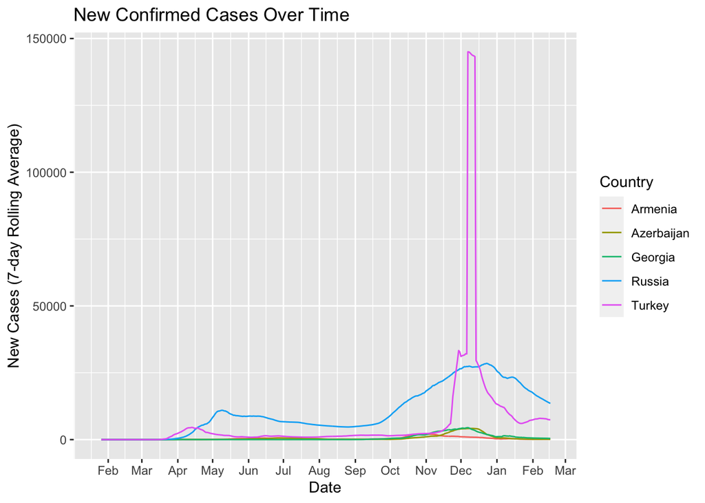

```r
ggplot(cases_long_country %>% filter(country %in% countries), aes(x=date, y=new_cases_7dayavg, color=country)) +  geom_line() + scale_x_date(date_breaks = "1 month", date_labels = "%b") + labs(x = "Date", y = "New Cases (7-day Rolling Average)", title = "New Confirmed Cases Over Time") + guides(color = guide_legend(title="Country"))
```

Since these countries all have different population sizes, it might be more informative to look at the new cases per-capita. For this we need to use a different data set available again from the Johns Hopkins [Github] (https://github.com/CSSEGISandData/COVID-19) page.

```r
#Reading in the population data
population_data <- read_csv("https://raw.githubusercontent.com/CSSEGISandData/COVID-19/master/csse_covid_19_data/UID_ISO_FIPS_LookUp_Table.csv")
```

Back to data cleaning for a minute here: Ultimately we just want the population information in our original case data set that we’ve been working with this entire time. So let’s try to join both data frames together, but before we do that, lets get rid of everything we don’t need from this new population data set.